# Modeling Interpretability with Workflow

Bruce Hartman

University of St. Francis

2026-08-05 Revised 2026-10-11T12:35:13

Abstract

We present some techniques for interpretability using modeling workflow. Workflow is based on `tidymodels`; interpretability uses `vip` and `pdp`.

# Introduction

Complex ‘black-box’ models are hard to interpret or explain. A new field called Explainable Artificial Intelligence (XAI) is arising. It computes objects that re supposedly easier to explain than the ‘black-box’ models that created the results. But it is also only a shadow of the original model. Remember Plato’s cave, in which people were seeing only shadows of the real objects, such as a chair or an animal, by the cave’s firelight. Such explanations may help decision makers understand what’s important driving the results predicted by the model.

# Packages

As usual, we have some standard packages.

```r
library(ISLR2)
library(mbadtools, quietly = TRUE) # some extra ggplot functions
```

# Interpretability Packages

There are quite a few of them. But the notion is still very confused in the data mining field. we are still experimenting with ways of obtaining what seems to be interpretability. We’ve chosen these to include in `mbadtools`.

## Variable Importance

Variable importance is crucial to the theory of interpretable or explainable models. There are many different ways to do this computation. We include some of them. The `vip` package computes variable importance for many different model types.

## Partial Dependence

Partial dependence plots are also key to explainability and interpretability of AI models. The `pdp` package helps in those computations and visualizations.

## Surrogates

Surrogate models produce a simple model that comes close to the black-box model. The `pre` package can produce surrogates.

# Data

We’ll use the `Boston` dataset from the `ISLR2` package.

```r
data("Boston")
Boston
```

|  | crim | zn | indus | chas | nox | rm | age | dis | rad | tax | ptratio | black | lstat | medv |
| --- | --- | --- | --- | --- | --- | --- | --- | --- | --- | --- | --- | --- | --- | --- |
| 1 | 0.00632 | 18.0 | 2.31 | 0 | 0.5380 | 6.575 | 65.2 | 4.0900 | 1 | 296 | 15.3 | 396.90 | 4.98 | 24.0 |
| 2 | 0.02731 | 0.0 | 7.07 | 0 | 0.4690 | 6.421 | 78.9 | 4.9671 | 2 | 242 | 17.8 | 396.90 | 9.14 | 21.6 |
| 3 | 0.02729 | 0.0 | 7.07 | 0 | 0.4690 | 7.185 | 61.1 | 4.9671 | 2 | 242 | 17.8 | 392.83 | 4.03 | 34.7 |
| 4 | 0.03237 | 0.0 | 2.18 | 0 | 0.4580 | 6.998 | 45.8 | 6.0622 | 3 | 222 | 18.7 | 394.63 | 2.94 | 33.4 |
| 5 | 0.06905 | 0.0 | 2.18 | 0 | 0.4580 | 7.147 | 54.2 | 6.0622 | 3 | 222 | 18.7 | 396.90 | 5.33 | 36.2 |
| 6 | 0.02985 | 0.0 | 2.18 | 0 | 0.4580 | 6.430 | 58.7 | 6.0622 | 3 | 222 | 18.7 | 394.12 | 5.21 | 28.7 |
| 7 | 0.08829 | 12.5 | 7.87 | 0 | 0.5240 | 6.012 | 66.6 | 5.5605 | 5 | 311 | 15.2 | 395.60 | 12.43 | 22.9 |
| 8 | 0.14455 | 12.5 | 7.87 | 0 | 0.5240 | 6.172 | 96.1 | 5.9505 | 5 | 311 | 15.2 | 396.90 | 19.15 | 27.1 |
| 9 | 0.21124 | 12.5 | 7.87 | 0 | 0.5240 | 5.631 | 100.0 | 6.0821 | 5 | 311 | 15.2 | 386.63 | 29.93 | 16.5 |
| 10 | 0.17004 | 12.5 | 7.87 | 0 | 0.5240 | 6.004 | 85.9 | 6.5921 | 5 | 311 | 15.2 | 386.71 | 17.10 | 18.9 |

[output cut: 496 more lines]

```r
Boston %>% skim
```

```
── Data Summary ────────────────────────
                           Values
Name                       Piped data
Number of rows             506
Number of columns          14
_______________________
Column type frequency:
  numeric                  14
________________________
Group variables            None
```

|  | skim_variable | n_missing | complete_rate | mean | sd | p0 | p25 | p50 | p75 | p100 | hist |
| --- | --- | --- | --- | --- | --- | --- | --- | --- | --- | --- | --- |
| 1 | crim | 0 | 1 | 3.61352356 | 8.6015451 | 0.00632 | 0.082045 | 0.25651 | 3.677083 | 88.9762 | ▇▁▁▁▁ |
| 2 | zn | 0 | 1 | 11.36363636 | 23.3224530 | 0.00000 | 0.000000 | 0.00000 | 12.500000 | 100.0000 | ▇▁▁▁▁ |
| 3 | indus | 0 | 1 | 11.13677866 | 6.8603529 | 0.46000 | 5.190000 | 9.69000 | 18.100000 | 27.7400 | ▇▆▁▇▁ |
| 4 | chas | 0 | 1 | 0.06916996 | 0.2539940 | 0.00000 | 0.000000 | 0.00000 | 0.000000 | 1.0000 | ▇▁▁▁▁ |
| 5 | nox | 0 | 1 | 0.55469506 | 0.1158777 | 0.38500 | 0.449000 | 0.53800 | 0.624000 | 0.8710 | ▇▇▆▅▁ |
| 6 | rm | 0 | 1 | 6.28463439 | 0.7026171 | 3.56100 | 5.885500 | 6.20850 | 6.623500 | 8.7800 | ▁▂▇▂▁ |
| 7 | age | 0 | 1 | 68.57490119 | 28.1488614 | 2.90000 | 45.025000 | 77.50000 | 94.075000 | 100.0000 | ▂▂▂▃▇ |
| 8 | dis | 0 | 1 | 3.79504269 | 2.1057101 | 1.12960 | 2.100175 | 3.20745 | 5.188425 | 12.1265 | ▇▅▂▁▁ |
| 9 | rad | 0 | 1 | 9.54940711 | 8.7072594 | 1.00000 | 4.000000 | 5.00000 | 24.000000 | 24.0000 | ▇▂▁▁▃ |
| 10 | tax | 0 | 1 | 408.23715415 | 168.5371161 | 187.00000 | 279.000000 | 330.00000 | 666.000000 | 711.0000 | ▇▇▃▁▇ |

[output cut: 4 more lines]

# Research Problem

The general problem involves predicting the median value `medv` of homes in the Boston communities by using the other features of the homes. To do well, this may take a very complicated algorithm that we might call a ‘black-box’ algorithm. We and possibly no one can actually understand exactly how it works.

We want to go further by being able to interpret our results in terms of a more naive idea that captures the ‘essence’ of the ‘black-box’ method.

There are two types of this interpretation.

- Global: we want to understand what features are important and what’s not for groups of homes.
- Specific; for a specific home, real or hypothetical, we want to be able to explain which features are important.

# Modeling

We have to do the modeling first. We won’t repeat the steps to determine the better model here. They are in Modeling Workflow Techniques. We just recompute the best random forest model from there.

```r
rf_spec <- rand_forest(
  mode = "regression",
  mtry = tune(),        # number of predictors sampled at each split
  min_n = tune(),       # minimum data points in a node
  trees = 1000          # keep high for stability
) %>% set_engine("ranger", importance = "permutation")

# Create workflow for RF
rf_workflow <- workflow() %>%
  add_model(rf_spec) %>%
  add_recipe(boston_recipe)

cv_folds <- vfold_cv(train_data, v = 5, strata = medv)

rf_params <- rf_workflow %>%
  extract_parameter_set_dials() %>%
  finalize(train_data)   # pass your training dataframe here

grid_rf <- grid_random(rf_params, size = 20)  # 20 random combos of the parameters.

set.seed(2025)
doParallel::registerDoParallel()  # optional: parallelize tuning if available

rf_tune_res <- tune_grid(
  rf_workflow,
  resamples = cv_folds,
  grid = grid_rf,
  metrics = metric_set(rmse, rsq), #choose metrics
  control = control_grid(save_pred = TRUE)
)

best_rmse <- select_best(rf_tune_res, metric="rmse")

final_rf_spec <- finalize_model(rf_spec, best_rmse)

final_rf_wf <- workflow() %>%
  add_model(final_rf_spec) %>%
  add_recipe(boston_recipe)

set.seed(2026)
final_rf_fit <- final_rf_wf %>% fit(data = train_data)
```

# Variable importance

For interpretation of ‘black box’ models we need to do something to explain the predictions. Read (Molnar, n.d.) for more on interpretability calculations. `tidymodels` builds in some ways to do this.

One such is variable importance. We can extract the fitted values and variable importance from the random forest from `parsnip` using `vip`. For the linear model, the variable importance is defined as the absolute value of the coefficient of the variable. We will use `vip::vi` to construct the data when there is no `variable.importance` created by the `parsnip` model.

Extract `parsnip` fit objects (we can construct this from both linear and rf models, but more later):

```r
rf_fit_obj <- extract_fit_parsnip(final_rf_fit)$fit
```

We can get Permutation-based importance (`ranger` set importance=“permutation”) immediately from the `ranger` random forest. The package `vip` (for variable importance plot) can be used to plot it.

However, we can get a common data object to plot by using `vip::vi`.for a linear model `vi` uses the absolute value of the t-statistic, and records the sign of the coefficient.

Here we just show the random forest, the best model.

```r
vi_rf = vi(rf_fit_obj)
```

We plot it..

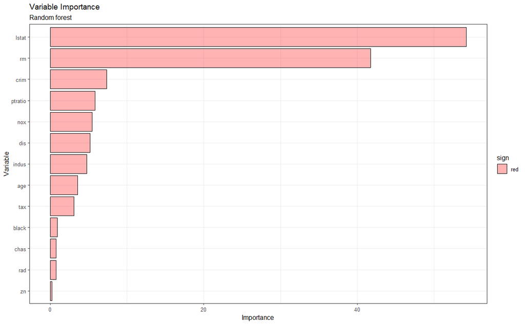

```r
vi_rf %>% gg_vip() + labs(subtitle="Random forest")
```

# Partial dependence

Partial dependence plots show the marginal effect of a feature (or two) on the predicted outcomes. (Molnar, n.d.) A partial dependence plot can show whether the relationship between the target and a feature is linear, monotonic, or more complex.

## Individual variables

Find the top variable from the random forest model:

```r
top_var_rf <- names(sort(rf_fit_obj$variable.importance,
                         decreasing = TRUE))[1]
cat("\nrf Top variable by importance: ", top_var_rf)
```

```
rf Top variable by importance:  lstat
```

Now we make partial dependence plots on the top variable (using `pdp` to extract the proper data). Construct the data for plotting:

```r
# use pdp to get data to plot
pd_rf <- partial(rf_fit_obj, pred.var = top_var_rf,
                   train = bake(recipes::prep(boston_recipe),
                                         train_data))
```

Plot the constructed data frames. Rug plots, to show the density of the axis variables, are a good idea, according to (Molnar, Chapter 19). I like the dot plots better.

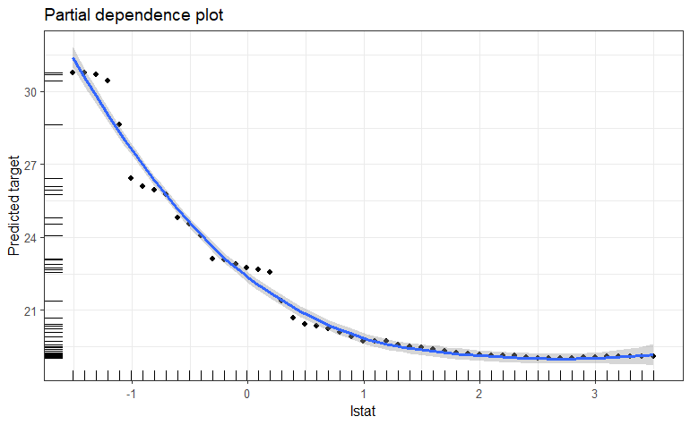

```r
gg_pdp(pd_rf)
```

The relation is clearly not linear for the random forest model. (It’s always linear for a linear model.) The random forest plot shows a steady decline till a break at an `lstat` of about 1 sd above the mean, when it flattens out. That value of `lstat` is 19.7941248, or around 20%.

The partial dependence plot is a global method: The method considers all instances and gives a statement about the global relationship of a feature with the predicted outcome.

We now plot partial dependence on the second-ranked variable, `rm`.

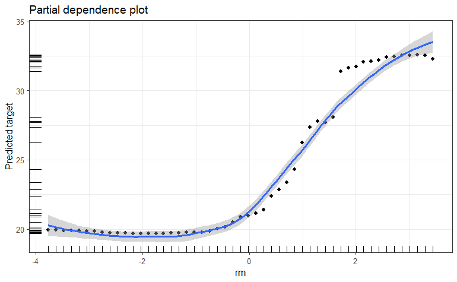

```r
# use pdp to get data to plot
pd_rf2 <- partial(rf_fit_obj, pred.var = "rm",
                   train = bake(prep(boston_recipe), train_data))
gg_pdp(pd_rf2)
```

It’s revealing; `medv` goes up with `rm`, but the random forest captures a distinctly nonlinear trend, where `medv` stays the same until about the mean value of `rm`, and then goes up quickly to a peak. The rug plot shows that data are concentrated at low and at high values of `medv`, with fewer points in the middle. The break point for the steep ascent is near 6.2846344, the mean number of rooms, about 6.25.

## Two variables

Generate 3D data.

```r
pd_rf3 <- partial(rf_fit_obj, pred.var = c("lstat","rm"),
                   train = bake(prep(boston_recipe), train_data), chull=TRUE)
```

Create plots. I wrote a function to do this in `mbadtools`. The level values express values of `medv`.

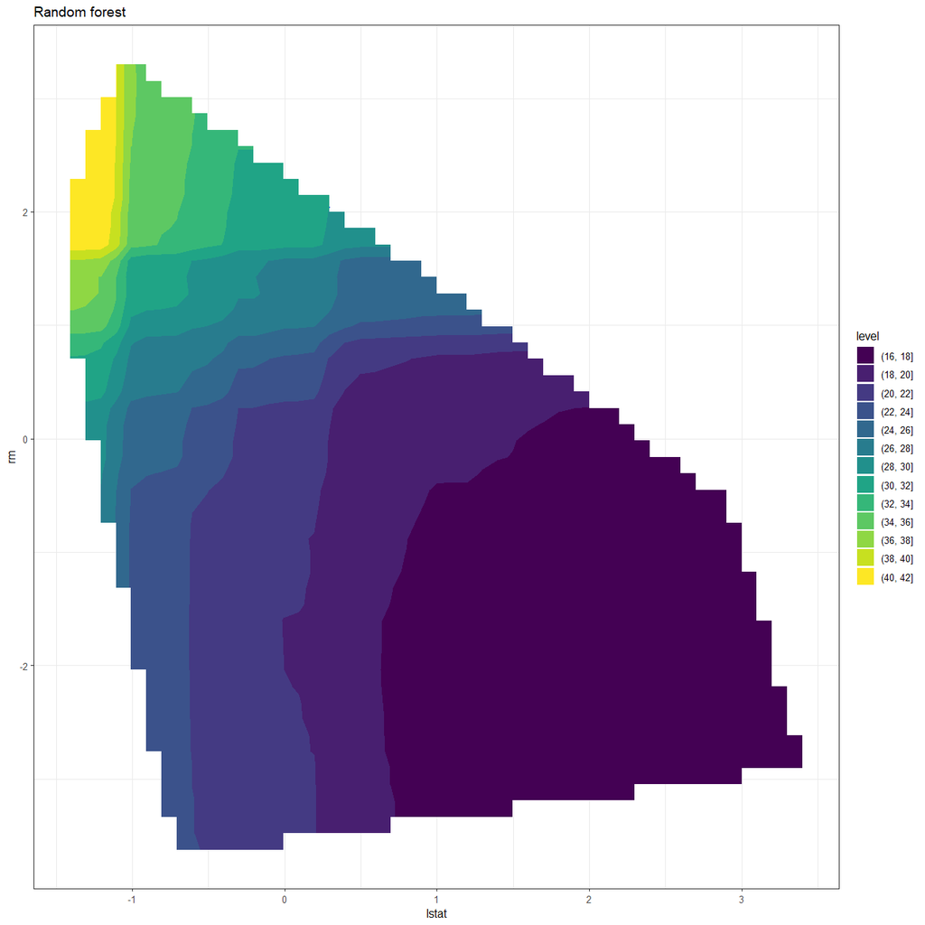

```r
gg_pdp3D(pd_rf3) +
             labs(title="Random forest")
```

## 3D with `plotly`

Contour plot:

```r
library(plotly)
plot_ly(pd_rf3, x = ~ lstat, y = ~ rm, z = ~ yhat,
                type="contour")
```

[interactive chart not shown]

Surface plot:

```r
R3 = pd_rf3 %>% as.matrix
conflicted::conflicts_prefer(plotly::layout)
plot_ly(z = ~R3, type="surface") %>%
  layout(title="Random forest pd plot",
         scene=list(
                    xaxis=list(title="lstat"),
                    yaxis=list(title="rm"),
                    zaxis=list(title="medv")
                    )
        ) %>% colorbar(title="medv")
```

[interactive chart not shown]

I have no idea why the `rm` axis scale in the `plotly` plots is in the hundreds! It’s not in the data. The `medv` and `lstat` axes are correct.

# Conclusion

We used `tidymodels` and `parsnip` which is part of `tidymodels` to model the `Boston` dataset predicting `medv` from the other variables. We tried a `ranger` randomForest model.

We found the importance of variables in the random forest, with `lstat` being most important. We made variable importance plots in Figure 1. Figure 2 shows partial dependence plots for `lstat` and Figure 3 shows them for `rm`.

The random forest model shows a propensity to ‘overfit’, as we would expect, since it randomly samples a lot of different trees using different drivers to obtain the predictions. It also ‘separates’ the most important variables more in importance.

# References

ChatGPT (2025) Model the Boston dataset with parsnip linear model and random forest. Retrieved 10/6/2025 from (https://chatgpt.com/c/68e41538-5894-8332-aeea-7ab0a0fd7b08)

Molnar, C. (2025). Interpretable Machine Learning: A Guide for Making Black Box Models Explainable (3rd ed.). christophm.github.io/interpretable-ml-book/ Partial Dependence Plots. Chapter 19, Retrieved online on 10/7/2025 from (https://christophm.github.io/interpretable-ml-book/pdp.html)

Greenwell, B. (2026) Package `vip` from R-universe Builds. Accessed on 7/28/2026 from R-universe. (https://bgreenwell.r-universe.dev/builds)

Biecek, P. and Burzykowski, T. (2020) Exploratory Model Analysis. (https://ema.drwhy.ai/)

Hartman, B. (2026) Modeling Workflow Interpretability (DOI:Modeling Workflow Interpretability.nb.html)